# TESS ML NOTEBOOK LISA BUGNET

—————————————- START ————————————————————–

Import needed packages, define data PATH.

```r
require(caret)
require(ggplot2)
require(randomForest)
PATH <- "/Users/lbugnet/DATA/TABLES/TESS_SIMU/"
```

Define train and test samples from TESS simulated data. Choice: clean (“CL”) or noisy (“NO”) data depending on the “TYPE_DATA” parameter.

```r
TYPE_DATA <- readline(prompt="Enter CL or NO: ")
CL
train = read.table(paste(PATH , "example_for_ml_7_",TYPE_DATA, "A3_2.txt", sep=""))
train<- train[,-c(9)] #remove columns you don't need
test=read.table(paste(PATH, "example_for_ml_7_",TYPE_DATA,"A3_1.txt", sep=""))
test<- test[,-c(9)] #remove columns you don't need
```

Define columns names:  
Fp07: FliPer calculated from 0.7 $\mu$Hz  
Fp10: FliPer calculated from 10 $\mu$Hz  
Fp30: FliPer calculated from 30 $\mu$Hz  
teff: effective temperatures from TESS simulated data  
diff: Fp30-Fp10  
diff2: Fp20-Fp07  
diff3: Fp10-Fp07  
Fp_med: FP07 - (FliPer calculated by the median of the PSD instead of the mean from 0.7 $\mu$Hz)  
Classe: input categories of TESS stars

```r
colnames(train) <- c("Fp07", "teff","Fp10", "Fp30" ,"diff","diff2", "diff3", "Fp_med",  "Classe")
colnames(test) <- c("Fp07", "teff","Fp10", "Fp30" ,"diff","diff2","diff3", "Fp_med", "Classe")
```

Plot training set:

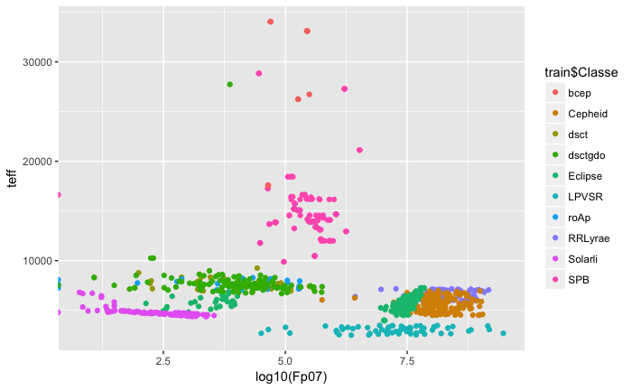

```r
ggplot(data=train,aes(x=log10(Fp07), y=teff, color= train$Classe, main=paste("train sample", TYPE_DATA))) + geom_point()
```

Training data preparation:

```r
#make formula
varNames <- names(train)
# Exclude ID or Response variable
varNames <- varNames[!varNames %in% c("Classe")]
# add + sign between exploratory variables
varNames1 <- paste(varNames, collapse = "+")
# Add response variable and convert to a formula object
rf.form <- as.formula(paste("Classe", varNames1, sep = " ~ "))
```

———————————- Training ————————————————————

Use RandomForest R alghorithm to train the model on the training set:

```r
RRandomForest_train <- randomForest( rf.form, data = train, ntree = 2000, mtry = sqrt(10), type = classification,  replace = FALSE, maxnodes = 60, nodesize = 5, importance = TRUE )
```

Performances:

```r
RRandomForest_train$importance #a matrix with nclass + 2 (for classification) or two (for regression) columns. For classification, the first nclass columns are the class-specific measures computed as mean descrease in accuracy. The nclass + 1st column is the mean descrease in accuracy over all classes. The last column is the mean decrease in Gini index.
```

```
             bcep      Cepheid         dsct    dsctgdo    Eclipse      LPVSR        roAp    RRLyrae
Fp07   0.23607799  0.230671796  0.003251909 0.24329621 0.24954489 0.09372981  0.05736644 0.28589759
teff   0.73257277  0.143171431  0.002544159 0.40022020 0.24355217 0.69282071  0.16354428 0.31486782
Fp10   0.10995021  0.002412195 -0.023476871 0.07975517 0.05975654 0.02756401  0.01653490 0.26023576
Fp30   0.16263302 -0.002103304 -0.024581284 0.07572918 0.03062930 0.08993924  0.03299780 0.48744037
diff   0.04224947  0.019510078 -0.011478691 0.09985432 0.14849526 0.04600457  0.01127671 0.01298254
diff2  0.22834905  0.231366848  0.001766898 0.23849970 0.24264884 0.09196172  0.06127252 0.26915987
diff3  0.09520184  0.088876745  0.028143605 0.19697536 0.07844746 0.15451712 -0.01708760 0.17914302
Fp_med 0.09824368  0.137381792 -0.014691144 0.09658126 0.15067245 0.04635155  0.01625041 0.21174119
          Solarli        SPB MeanDecreaseAccuracy MeanDecreaseGini
Fp07   0.38565568 0.18559680           0.23321734         91.34771
teff   0.54487974 0.73296776           0.39943919        197.80178
Fp10   0.14715579 0.02675188           0.07113851         28.39867
Fp30   0.19038994 0.14141519           0.11101464         44.54744
diff   0.06061660 0.01812236           0.06525113         21.50041
diff2  0.36458796 0.18290122           0.22655180         90.13398
diff3  0.27968298 0.06598020           0.12593694         67.51659
Fp_med 0.06308238 0.04187607           0.10194932         49.65937
```

Plot of error VS number of trees

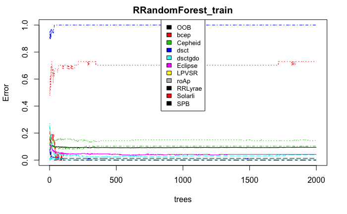

```r
plot(RRandomForest_train)
legend("top", colnames(RRandomForest_train$err.rate),col=1:10,cex=0.8,fill=1:10)
```

OOB estimate error and Confusion matric for the training set:

```r
RRandomForest_train
```

```
Call:
 randomForest(formula = rf.form, data = train, ntree = 2000, mtry = sqrt(10),      type = classification, replace = FALSE, maxnodes = 60, nodesize = 5,      importance = TRUE)
               Type of random forest: classification
                     Number of trees: 2000
No. of variables tried at each split: 3

        OOB estimate of  error rate: 9.44%
Confusion matrix:
        bcep Cepheid dsct dsctgdo Eclipse LPVSR roAp RRLyrae Solarli SPB class.error
bcep      21       0    0       0       0     0    0       0       0   0 0.000000000
Cepheid    0     137    0       0      17     1    0       5       0   0 0.143750000
dsct       0       0    0      33       0     0    0       0       0   0 1.000000000
dsctgdo    0       0    2     150       1     0    2       0       0   1 0.038461538
Eclipse    0       2    0       2     271     0    0       2       6   0 0.042402827
LPVSR      0       0    0       0       0    68    0       0       0   0 0.000000000
roAp       0       0    0      27       0     0   10       0       0   0 0.729729730
RRLyrae    0       1    0       0       9     0    0      87       0   0 0.103092784
Solarli    0       0    0       1       1     0    0       0     148   0 0.013333333
SPB        0       0    0       1       0     0    0       0       0 202 0.004926108
```

PLots of accuracy and Gini index: Gives influences of parameters on the training

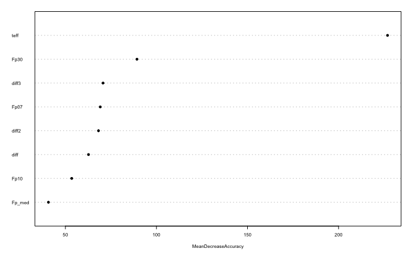

```r
varImpPlot(RRandomForest_train, type=1, pch=19, col=1, cex=.5, main="")#accuracy
```

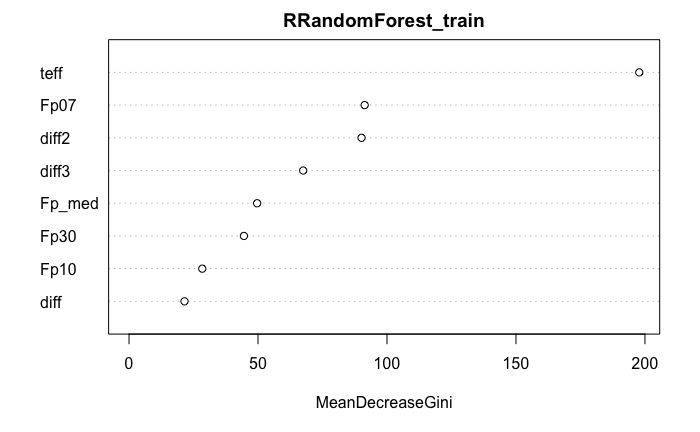

```r
varImpPlot(RRandomForest_train, type=2)#Gini
```

———————————— Testing on Test Data ———————————————

```r
###testing
test$predicted <- predict(RRandomForest_train, test)
```

```r
conf <- confusionMatrix(data = test$predicted, reference = test$Classe)
print(conf)
```

```
Confusion Matrix and Statistics

          Reference
Prediction bcep Cepheid dsct dsctgdo Eclipse LPVSR roAp RRLyrae Solarli SPB
   bcep      30       0    0       0       0     0    0       0       0   0
   Cepheid    0     124    0       0       4     0    0       2       0   0
   dsct       0       0    0       0       0     0    0       0       0   0
   dsctgdo    0       0   27     169       2     0   21       2       0   0
   Eclipse    0      28    0       1     234     0    0       6       0   0
   LPVSR      0       3    0       0       1    78    0       0       0   0
   roAp       0       0    0       2       0     0    9       0       0   0
   RRLyrae    0       5    0       0       0     0    0      90       0   0
   Solarli    0       0    0       0       2     0    0       0     155   0
   SPB        0       0    0       0       0     0    0       0       0 154

Overall Statistics

               Accuracy : 0.9077
                 95% CI : (0.8895, 0.9239)
    No Information Rate : 0.2115
    P-Value [Acc > NIR] : < 2.2e-16

                  Kappa : 0.8923
 Mcnemar's Test P-Value : NA

Statistics by Class:

                     Class: bcep Class: Cepheid Class: dsct Class: dsctgdo Class: Eclipse Class: LPVSR
Sensitivity              1.00000         0.7750      0.0000         0.9826         0.9630      1.00000
Specificity              1.00000         0.9939      1.0000         0.9468         0.9614      0.99627
Pos Pred Value           1.00000         0.9538         NaN         0.7647         0.8699      0.95122
Neg Pred Value           1.00000         0.9647      0.9765         0.9968         0.9898      1.00000
Prevalence               0.02611         0.1393      0.0235         0.1497         0.2115      0.06789
Detection Rate           0.02611         0.1079      0.0000         0.1471         0.2037      0.06789
Detection Prevalence     0.02611         0.1131      0.0000         0.1923         0.2341      0.07137
Balanced Accuracy        1.00000         0.8845      0.5000         0.9647         0.9622      0.99813
                     Class: roAp Class: RRLyrae Class: Solarli Class: SPB
Sensitivity             0.300000        0.90000         1.0000      1.000
Specificity             0.998213        0.99523         0.9980      1.000
Pos Pred Value          0.818182        0.94737         0.9873      1.000
Neg Pred Value          0.981547        0.99051         1.0000      1.000
Prevalence              0.026110        0.08703         0.1349      0.134
Detection Rate          0.007833        0.07833         0.1349      0.134
Detection Prevalence    0.009574        0.08268         0.1366      0.134
Balanced Accuracy       0.649106        0.94762         0.9990      1.000
```

————————————– Plot results: —————————————————

Test sample predicted

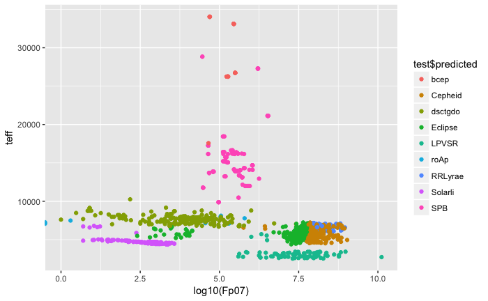

```r
ggplot(data=test,aes(x=log10(Fp07), y=teff, color= test$predicted, main=paste("predicted classes", TYPE_DATA))) + geom_point()
```

Test sample real classes

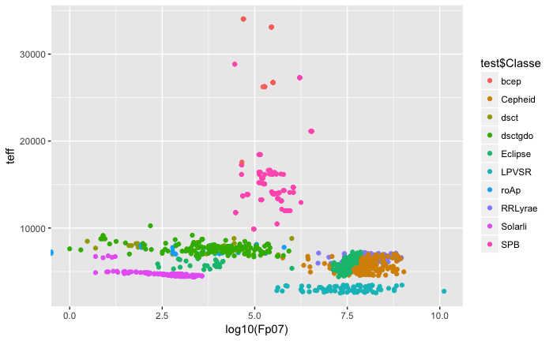

```r
ggplot(data=test,aes(x=log10(Fp07), y=teff, color= test$Classe, main=paste("test real classes", TYPE_DATA))) + geom_point()
```